# John-s-Hopkins-Corona-Database

Rahsa Jaber

4/22/2020

Data Preparation and Manipulation

1.We first prepare and aggregate the data.

1. load the Corona Confirmed Cases Narrow, the Corona Confirmed Deaths Narrow, and the Corona Confirmed Recovered Narrow datasets directly from the John’s Hopkins website.

```r
Corona.Cases <- read.csv(url("https://data.humdata.org/hxlproxy/data/download/time_series_covid19_confirmed_global_narrow.csv?dest=data_edit&filter01=merge&merge-url01=https%3A%2F%2Fdocs.google.com%2Fspreadsheets%2Fd%2Fe%2F2PACX-1vTglKQRXpkKSErDiWG6ycqEth32MY0reMuVGhaslImLjfuLU0EUgyyu2e-3vKDArjqGX7dXEBV8FJ4f%2Fpub%3Fgid%3D1326629740%26single%3Dtrue%26output%3Dcsv&merge-keys01=%23country%2Bname&merge-tags01=%23country%2Bcode%2C%23region%2Bmain%2Bcode%2C%23region%2Bsub%2Bcode%2C%23region%2Bintermediate%2Bcode&filter02=merge&merge-url02=https%3A%2F%2Fdocs.google.com%2Fspreadsheets%2Fd%2Fe%2F2PACX-1vTglKQRXpkKSErDiWG6ycqEth32MY0reMuVGhaslImLjfuLU0EUgyyu2e-3vKDArjqGX7dXEBV8FJ4f%2Fpub%3Fgid%3D398158223%26single%3Dtrue%26output%3Dcsv&merge-keys02=%23adm1%2Bname&merge-tags02=%23country%2Bcode%2C%23region%2Bmain%2Bcode%2C%23region%2Bsub%2Bcode%2C%23region%2Bintermediate%2Bcode&merge-replace02=on&merge-overwrite02=on&filter03=explode&explode-header-att03=date&explode-value-att03=value&filter04=rename&rename-oldtag04=%23affected%2Bdate&rename-newtag04=%23date&rename-header04=Date&filter05=rename&rename-oldtag05=%23affected%2Bvalue&rename-newtag05=%23affected%2Binfected%2Bvalue%2Bnum&rename-header05=Value&filter06=clean&clean-date-tags06=%23date&filter07=sort&sort-tags07=%23date&sort-reverse07=on&filter08=sort&sort-tags08=%23country%2Bname%2C%23adm1%2Bname&tagger-match-all=on&tagger-default-tag=%23affected%2Blabel&tagger-01-header=province%2Fstate&tagger-01-tag=%23adm1%2Bname&tagger-02-header=country%2Fregion&tagger-02-tag=%23country%2Bname&tagger-03-header=lat&tagger-03-tag=%23geo%2Blat&tagger-04-header=long&tagger-04-tag=%23geo%2Blon&header-row=1&url=https%3A%2F%2Fraw.githubusercontent.com%2FCSSEGISandData%2FCOVID-19%2Fmaster%2Fcsse_covid_19_data%2Fcsse_covid_19_time_series%2Ftime_series_covid19_confirmed_global.csv"), comment.char="#")

Corona.Deaths <- read.csv(url("https://data.humdata.org/hxlproxy/data/download/time_series_covid19_deaths_global_narrow.csv?dest=data_edit&filter01=merge&merge-url01=https%3A%2F%2Fdocs.google.com%2Fspreadsheets%2Fd%2Fe%2F2PACX-1vTglKQRXpkKSErDiWG6ycqEth32MY0reMuVGhaslImLjfuLU0EUgyyu2e-3vKDArjqGX7dXEBV8FJ4f%2Fpub%3Fgid%3D1326629740%26single%3Dtrue%26output%3Dcsv&merge-keys01=%23country%2Bname&merge-tags01=%23country%2Bcode%2C%23region%2Bmain%2Bcode%2C%23region%2Bsub%2Bcode%2C%23region%2Bintermediate%2Bcode&filter02=merge&merge-url02=https%3A%2F%2Fdocs.google.com%2Fspreadsheets%2Fd%2Fe%2F2PACX-1vTglKQRXpkKSErDiWG6ycqEth32MY0reMuVGhaslImLjfuLU0EUgyyu2e-3vKDArjqGX7dXEBV8FJ4f%2Fpub%3Fgid%3D398158223%26single%3Dtrue%26output%3Dcsv&merge-keys02=%23adm1%2Bname&merge-tags02=%23country%2Bcode%2C%23region%2Bmain%2Bcode%2C%23region%2Bsub%2Bcode%2C%23region%2Bintermediate%2Bcode&merge-replace02=on&merge-overwrite02=on&filter03=explode&explode-header-att03=date&explode-value-att03=value&filter04=rename&rename-oldtag04=%23affected%2Bdate&rename-newtag04=%23date&rename-header04=Date&filter05=rename&rename-oldtag05=%23affected%2Bvalue&rename-newtag05=%23affected%2Binfected%2Bvalue%2Bnum&rename-header05=Value&filter06=clean&clean-date-tags06=%23date&filter07=sort&sort-tags07=%23date&sort-reverse07=on&filter08=sort&sort-tags08=%23country%2Bname%2C%23adm1%2Bname&tagger-match-all=on&tagger-default-tag=%23affected%2Blabel&tagger-01-header=province%2Fstate&tagger-01-tag=%23adm1%2Bname&tagger-02-header=country%2Fregion&tagger-02-tag=%23country%2Bname&tagger-03-header=lat&tagger-03-tag=%23geo%2Blat&tagger-04-header=long&tagger-04-tag=%23geo%2Blon&header-row=1&url=https%3A%2F%2Fraw.githubusercontent.com%2FCSSEGISandData%2FCOVID-19%2Fmaster%2Fcsse_covid_19_data%2Fcsse_covid_19_time_series%2Ftime_series_covid19_deaths_global.csv"), comment.char="#")

Corona.Recovered <- read.csv(url("https://data.humdata.org/hxlproxy/data/download/time_series_covid19_recovered_global_narrow.csv?dest=data_edit&filter01=merge&merge-url01=https%3A%2F%2Fdocs.google.com%2Fspreadsheets%2Fd%2Fe%2F2PACX-1vTglKQRXpkKSErDiWG6ycqEth32MY0reMuVGhaslImLjfuLU0EUgyyu2e-3vKDArjqGX7dXEBV8FJ4f%2Fpub%3Fgid%3D1326629740%26single%3Dtrue%26output%3Dcsv&merge-keys01=%23country%2Bname&merge-tags01=%23country%2Bcode%2C%23region%2Bmain%2Bcode%2C%23region%2Bsub%2Bcode%2C%23region%2Bintermediate%2Bcode&filter02=merge&merge-url02=https%3A%2F%2Fdocs.google.com%2Fspreadsheets%2Fd%2Fe%2F2PACX-1vTglKQRXpkKSErDiWG6ycqEth32MY0reMuVGhaslImLjfuLU0EUgyyu2e-3vKDArjqGX7dXEBV8FJ4f%2Fpub%3Fgid%3D398158223%26single%3Dtrue%26output%3Dcsv&merge-keys02=%23adm1%2Bname&merge-tags02=%23country%2Bcode%2C%23region%2Bmain%2Bcode%2C%23region%2Bsub%2Bcode%2C%23region%2Bintermediate%2Bcode&merge-replace02=on&merge-overwrite02=on&filter03=explode&explode-header-att03=date&explode-value-att03=value&filter04=rename&rename-oldtag04=%23affected%2Bdate&rename-newtag04=%23date&rename-header04=Date&filter05=rename&rename-oldtag05=%23affected%2Bvalue&rename-newtag05=%23affected%2Binfected%2Bvalue%2Bnum&rename-header05=Value&filter06=clean&clean-date-tags06=%23date&filter07=sort&sort-tags07=%23date&sort-reverse07=on&filter08=sort&sort-tags08=%23country%2Bname%2C%23adm1%2Bname&tagger-match-all=on&tagger-default-tag=%23affected%2Blabel&tagger-01-header=province%2Fstate&tagger-01-tag=%23adm1%2Bname&tagger-02-header=country%2Fregion&tagger-02-tag=%23country%2Bname&tagger-03-header=lat&tagger-03-tag=%23geo%2Blat&tagger-04-header=long&tagger-04-tag=%23geo%2Blon&header-row=1&url=https%3A%2F%2Fraw.githubusercontent.com%2FCSSEGISandData%2FCOVID-19%2Fmaster%2Fcsse_covid_19_data%2Fcsse_covid_19_time_series%2Ftime_series_covid19_recovered_global.csv"), comment.char="#")

Corona.Cases$Date <- as.Date(Corona.Cases$Date)
Corona.Deaths$Date <- as.Date(Corona.Deaths$Date)
Corona.Recovered$Date <- as.Date(Corona.Recovered$Date)

class(Corona.Cases$Date)
```

```
## [1] "Date"
```

2. Create new data-frames named cases.agg, deaths.agg, and recovered.agg which aggregate the sum of Corona cases, deaths, and recovered respectively over the different countries’ provinces. To do this, aggregate Value using only the country and date features, ignoring all other features .To achieve the aggregation use the aggregate function. In addition, order the data-frame first by Country and then by Date (increasing order). The columns of each of the two resulting data-frames should be Country.Region, Date, Value.

```r
cases.agg <- aggregate(Value ~ Country.Region + Date, data = Corona.Cases, FUN = sum)
cases.agg <- cases.agg[order(cases.agg$Country.Region, cases.agg$Date, decreasing = FALSE), ]

deaths.agg <- aggregate(Value ~ Country.Region + Date, data = Corona.Deaths, FUN = sum)
deaths.agg <- deaths.agg[order(deaths.agg$Country.Region, deaths.agg$Date, decreasing = FALSE), ]

recovered.agg <- aggregate(Value ~ Country.Region + Date, data = Corona.Recovered, FUN = sum)
recovered.agg <- recovered.agg[order(recovered.agg$Country.Region, recovered.agg$Date, decreasing = FALSE), ]

head(recovered.agg)
```

```
##     Country.Region       Date Value
## 1      Afghanistan 2020-01-22     0
## 189    Afghanistan 2020-01-23     0
## 377    Afghanistan 2020-01-24     0
## 565    Afghanistan 2020-01-25     0
## 753    Afghanistan 2020-01-26     0
## 941    Afghanistan 2020-01-27     0
```

```r
#Aggregating using tidyverse and the pipe:
cases.agg2 <- Corona.Cases %>% select(Country.Region, Date, Value) %>%  group_by(Country.Region,Date) %>% summarise(total = sum(Value))
deaths.agg2 <- Corona.Deaths %>% select(Country.Region, Date, Value) %>%  group_by(Country.Region,Date) %>% summarise(total = sum(Value))
recovered.agg2 <- Corona.Recovered %>% select(Country.Region, Date, Value) %>%  group_by(Country.Region,Date) %>% summarise(total = sum(Value))

head(deaths.agg2)
```

```
## # A tibble: 6 x 3
## # Groups:   Country.Region [1]
##   Country.Region Date       total
##   <chr>          <date>     <int>
## 1 Afghanistan    2020-01-22     0
## 2 Afghanistan    2020-01-23     0
## 3 Afghanistan    2020-01-24     0
## 4 Afghanistan    2020-01-25     0
## 5 Afghanistan    2020-01-26     0
## 6 Afghanistan    2020-01-27     0
```

```r
#Verifying output of two approaches is the same:

all(cases.agg==cases.agg2)
```

```
## [1] TRUE
```

```r
ref <- '2020-03-31'
Mar.cases <- cases.agg  %>% filter(Date ==ref)%>% arrange(-Value) %>% head(10) %>% arrange(Country.Region)

Mar.deaths <- deaths.agg  %>%  filter(Date ==ref)%>% filter(Country.Region %in% Mar.cases$Country.Region)%>%  arrange(Country.Region)

Mar.recovered <- recovered.agg %>%  filter(Date ==ref)%>% filter(Country.Region %in% Mar.cases$Country.Region)%>%  arrange(Country.Region)

Top.cases <-  data.frame(country.region = Mar.cases$Country.Region, total.cases = Mar.cases$Value, deaths = Mar.deaths$Value, recovered = Mar.recovered$Value) %>% arrange(-total.cases)

head(Top.cases)
```

```
##   country.region total.cases deaths recovered
## 1             US      192091   5249      7024
## 2          Italy      105792  12428     15729
## 3          Spain       95923   8464     19259
## 4          China       82279   3309     76206
## 5        Germany       71808    775     16100
## 6         France       52827   3532      9513
```

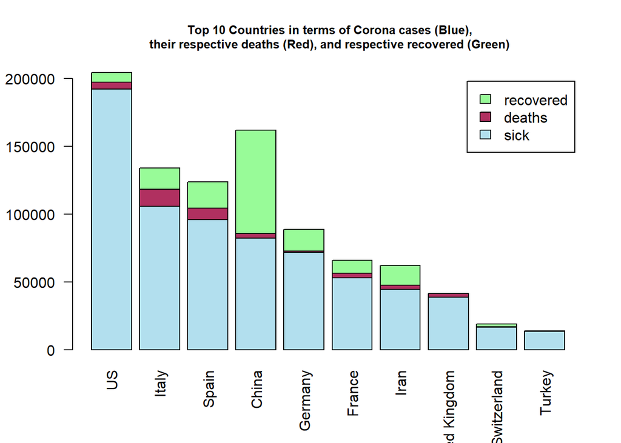

```r
barplot(t(as.matrix(Top.cases[2:4])), names.arg = Top.cases$country.region,  beside = FALSE, legend.text = c("sick", "deaths", "recovered") , col = c("lightblue2", "maroon","palegreen"), las=2,cex.main=0.8,main = " Top 10 Countries in terms of Corona cases (Blue),\n their respective deaths (Red), and respective recovered (Green)")
```

Analysis of Daily New Corona Cases and Deaths